# Assignment #1 Dataset selection and initial processing

Xinyi Zhang

## R Markdown

Download data, the data used for this assignment is from here: https://www.ncbi.nlm.nih.gov/geo/query/acc.cgi?acc=GSE150392 The GEOquery library is used for downloading the corresponding count matrix. Becaues the getGEOSuppFiles function will create a folder and save the count matrix into the folder, here we used a if..else.. to check if the data exists to avoid download the data everytime.

```r
library(GEOquery)
if (!dir.exists('GSE150392')){
  supfiles = getGEOSuppFiles('GSE150392')
} else {
  print("Dir already exists and data already downloaded!")
}
```

Check how many Supplementary files are included for this study. Then, download the supplementary data (i.e., the count matrix) to local computer.

```r
nrow(supfiles)
```

```
## [1] 1
```

```r
supfiles = rownames(supfiles)
mat = read.delim(supfiles[1],header=TRUE)
```

Preprocess the matrix data and convert it to a matrix/dataFrame. From the GEO webpage, we can know that this study contains three replicates for each treatment group, so the matirx should have 7 columns (1st col is the gene symbol). The column names can be changed based on the original column names.

```r
library(stringr)
mat<-data.frame(str_split_fixed(mat$X.Cov1.Cov2.Cov3.Mock1.Mock2.Mock3, ",", 7))
head(mat)
```

```
##                            X1   X2   X3  X4   X5   X6   X7
## 1   ENSG00000000003.15_TSPAN6 1270 1013 848 4571 5500 4844
## 2      ENSG00000000005.6_TNMD  121  125  49 3220 6435 2977
## 3     ENSG00000000419.12_DPM1 1023 1045 674 2404 4794 1819
## 4    ENSG00000000457.14_SCYL3 1049  713 692  854  356 1015
## 5 ENSG00000000460.17_C1orf112  211  158  90  576  195  477
## 6      ENSG00000000938.13_FGR    9    8   2   10    5    0
```

```r
colnames(mat)<-c("Symbol","Cov1","Cov2","Cov3","Mock1","Mock2","Mock3")
symbol<-mat[,1]
mat<-data.frame(apply(mat[,c(2:7)], 2, function(x) as.numeric(as.character(x))))
mat$symbol<-symbol
mat<-mat[,c(7,1,2,3,4,5,6)]
head(mat)
```

```
##                        symbol Cov1 Cov2 Cov3 Mock1 Mock2 Mock3
## 1   ENSG00000000003.15_TSPAN6 1270 1013  848  4571  5500  4844
## 2      ENSG00000000005.6_TNMD  121  125   49  3220  6435  2977
## 3     ENSG00000000419.12_DPM1 1023 1045  674  2404  4794  1819
## 4    ENSG00000000457.14_SCYL3 1049  713  692   854   356  1015
## 5 ENSG00000000460.17_C1orf112  211  158   90   576   195   477
## 6      ENSG00000000938.13_FGR    9    8    2    10     5     0
```

From the gene symbol in the matrix, we can see these symbols contain ensemble gene ID and gene symbol, it is better to use two columns to hold these info.

```r
symbol<-data.frame(str_split_fixed(mat[,1],"_",2))
colnames(symbol)<-c("GeneID","GeneSymbol")

mat<-cbind(symbol,mat)
mat$symbol<-NULL
```

Now, we check the overall quailty of the data.

```r
dim(mat)
```

```
## [1] 36941     8
```

This data contains 36941 genes with 3 replicates for each treatment group. Now we want to see if any genes are duplicated in this data.

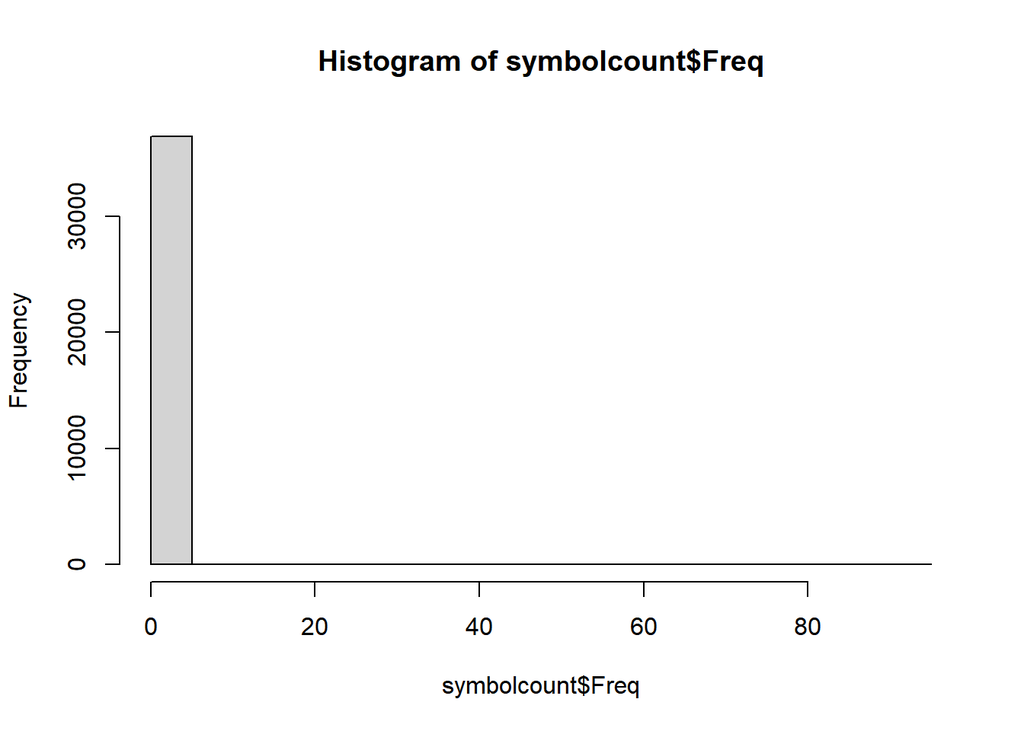

```r
symbolcount<-data.frame(table(mat$GeneSymbol))
hist(symbolcount$Freq)
```

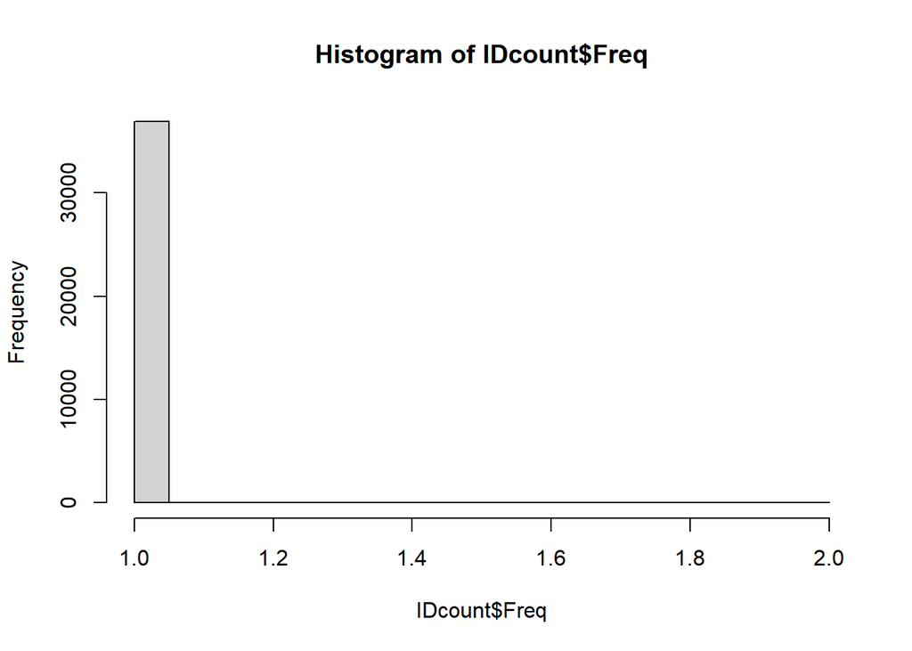

```r
IDcount<-data.frame(table(mat$GeneID))
hist(IDcount$Freq)
```

```r
library(HGNChelper)
hugocheck<-checkGeneSymbols(mat$GeneSymbol,species = "human")
```

```
## Maps last updated on: Thu Oct 24 12:31:05 2019
```

```r
colnames(hugocheck)[1]<-c("GeneSymbol")
mat<-merge(mat,hugocheck,by="GeneSymbol",all=FALSE)
mat<-mat[mat$Approved == "TRUE",]
mat$GeneSymbol<-NULL
mat$GeneID<-NULL
mat$Approved<-NULL
mat<-mat[,c(7,1,2,3,4,5,6)]
colnames(mat)[1]<-"Symbol"
```

```r
mat<-mat[rowSums(mat == 0) < 2, ]
mat<-unique(mat)
symbolcount<-data.frame(table(mat$Symbol))
genewithmuiltiplerow<-symbolcount[symbolcount$Freq != 1,]
tp<-mat[mat$Symbol %in% genewithmuiltiplerow$Var1,]
tp<-aggregate(cbind(Cov1,Cov2,Cov3,Mock1,Mock2,Mock3) ~ Symbol, data = tp, FUN = mean, na.rm = TRUE)
genekeep<-symbolcount[symbolcount$Freq == 1,]
mat<-mat[mat$Symbol %in% genekeep$Var1,]
mat<-rbind(mat,tp)
```

Now, we can normlize our data. The normalized_counts is the final data frame.

```r
library(edgeR)
```

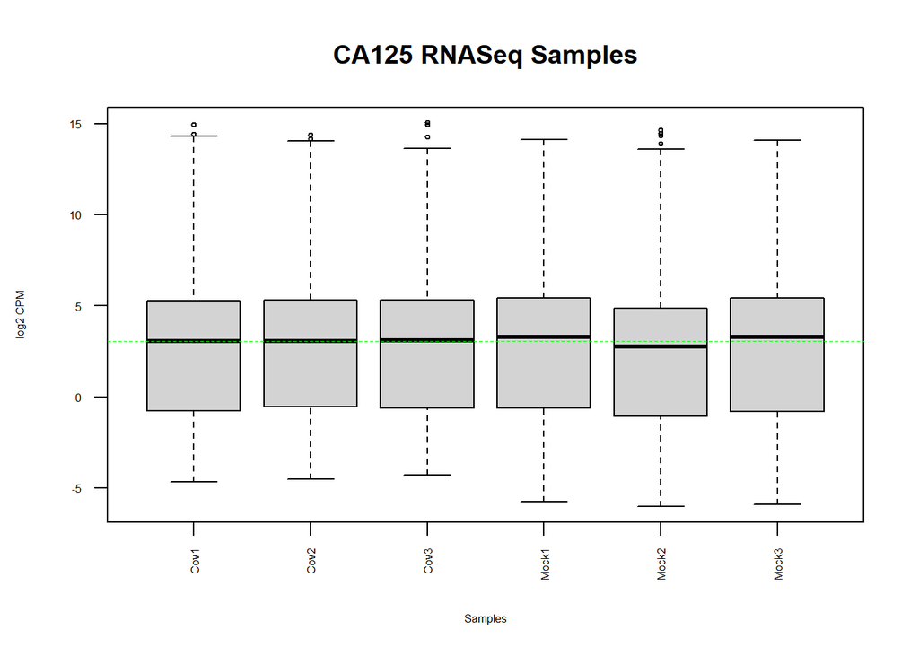

```r
rownames(mat)<-mat$Symbol
matx<-mat[,c(2:7)]
data2plot <- log2(cpm(matx))
boxplot(data2plot, xlab = "Samples", ylab = "log2 CPM",las = 2, cex = 0.5, cex.lab = 0.5,cex.axis = 0.5, main = "CA125 RNASeq Samples")
abline(h = median(apply(data2plot, 2, median)),col = "green", lwd = 0.6, lty = "dashed")
```

```r
d = DGEList(counts=matx)
d =calcNormFactors(d)
normalized_counts <- cpm(d)
```